# Homework: Packages, Scripts, Documents, and Functions

Susan Vanderplas

## Instructions

This homework has two main problems. In the FizzBuzz section, you should only modify the code chunks. In the Packages/Procedures section, you should modify the text (anything that doesn’t have a `###` in front of it) and the code chunks. Feel free to add additional code chunks as necessary.

Make sure you also edit the author name at the top of the document.

When you are finished with the assignment:

1. Save the file as 03_Lastname_Firstname.Rmd and compile it
2. Commit the Rmd file and corresponding html file to your homework git repo
3. Push the commit to github
4. Locate the Rmd file on github and click on the SHA link for the file
5. Paste the url of the resulting page into Canvas to submit your assignment.

Your assignment must compile on a different computer as long as the saspath is set correctly for that machine.

## FizzBuzz Functions

In the R chunk below, write a function which will solve this problem. Do not change the function name or parameter name.

Show the results from running your function on the integers 1-20, as well as a sequence of 10 random integers between 0 and 100. (This code is already written for you).

```r
fizzbuzz <- function(x) {
  # FizzBuzz code goes here
  # This is a crude way to solve this problem, and not the most efficient,
  # but it's only using things you know at the moment...
  # If you're still writing code like this at the end of class, I've failed :)

  fb_res <- rep("", length(x))
  for (i in 1:length(x)) {
    xi <- x[i]
    if (xi %% 15 == 0) {        # Handle multiples of 3 and 5 (so 15) first
      str <- "FizzBuzz"
    } else if (xi %% 5 == 0) { # Then, you know anything that isn't a multiple of
      str <- "Buzz"            # 15 and is a multiple of 5 isn't divisible by 3
    } else if (xi %% 3 == 0) { # And so if something isn't divisible by 5, you
      str <- "Fizz"            # also need to check divisibility by 3
    } else {
      str <- as.character(xi)  # Then, if none of those conditions hold, print the
    }                          # number
    fb_res[i] <- str

    # print(str) # This prints things out one by one
    # print statements like this are great for debugging, but you
    # probably want to comment them out when you're done with that stage
  }
  # Return a data frame with columns x and res
  return(data.frame(x = x, res = fb_res))
}

fizzbuzz(1:20)
```

```
    x      res
1   1        1
2   2        2
3   3     Fizz
4   4        4
5   5     Buzz
6   6     Fizz
7   7        7
8   8        8
9   9     Fizz
10 10     Buzz
11 11       11
12 12     Fizz
13 13       13
14 14       14
15 15 FizzBuzz
16 16       16
17 17       17
18 18     Fizz
19 19       19
20 20     Buzz
```

```r
fizzbuzz(sample(1:100, 10)) # sample 10 values from 1 to 100
```

```
    x      res
1  93     Fizz
2  53       53
3  27     Fizz
4  33     Fizz
5  45 FizzBuzz
6  79       79
7  62       62
8  17       17
9  15 FizzBuzz
10 35     Buzz
```

```r
# You can also do this slightly differently, by defining fizzbuzz as a function
# that only works on one number.
fizzbuzz <- function(x) {
  if (x %% 15 == 0) {        # Handle multiples of 3 and 5 (so 15) first
    str <- "FizzBuzz"
  } else if (x %% 5 == 0) { # Then, you know anything that isn't a multiple of
    str <- "Buzz"           # 15 and is a multiple of 5 isn't divisible by 3
  } else if (x %% 3 == 0) { # And so if something isn't divisible by 5, you
    str <- "Fizz"           # also need to check divisibility by 3
  } else {
    str <- as.character(x)  # Then, if none of those conditions hold, print the
  }                         # number
  return(str)
}

# The for loop then has to go outside of the function
for (i in 1:20) print(fizzbuzz(i))
```

```
[1] "1"
[1] "2"
[1] "Fizz"
[1] "4"
[1] "Buzz"
[1] "Fizz"
[1] "7"
[1] "8"
[1] "Fizz"
[1] "Buzz"
[1] "11"
[1] "Fizz"
[1] "13"
[1] "14"
[1] "FizzBuzz"
[1] "16"
[1] "17"
[1] "Fizz"
[1] "19"
[1] "Buzz"
```

```r
z <- sample(1:100, 10)
zres <- c() # empty vector
for (i in z) zres <- c(zres, fizzbuzz(i)) # append result to vector
data.frame(z, zres) # print out z and zres in columns
```

```
    z     zres
1  28       28
2  59       59
3  21     Fizz
4  16       16
5  40     Buzz
6  34       34
7  87     Fizz
8  75 FizzBuzz
9  66     Fizz
10 62       62
```

```r
# Invoking the function for a vector will then create a warning
# (and the results are wrong)
fizzbuzz(1:20)
```

```
 [1] "1"  "2"  "3"  "4"  "5"  "6"  "7"  "8"  "9"  "10" "11" "12" "13" "14" "15"
[16] "16" "17" "18" "19" "20"
```

If you want to expand beyond what we’ve learned so far, here’s another easy way to apply the function to a vector of numbers.

```r
# This is a simpler way to write the loop -- and more generalizable, because it
# returns a data structure that we can use elsewhere more easily
library(purrr)
zres <- map_chr(1:20, fizzbuzz) # this runs fizzbuzz for each integer 1:20 and returns a character vector
data.frame(z = 1:20, zres)
```

```
    z     zres
1   1        1
2   2        2
3   3     Fizz
4   4        4
5   5     Buzz
6   6     Fizz
7   7        7
8   8        8
9   9     Fizz
10 10     Buzz
11 11       11
12 12     Fizz
13 13       13
14 14       14
15 15 FizzBuzz
16 16       16
17 17       17
18 18     Fizz
19 19       19
20 20     Buzz
```

In the sas chunk, write similar code which will solve this problem.

```
/* This function uses the cats method without nested if statements */
proc iml;

start fizzbuzz(x);
/* FizzBuzz code goes here */
  a = '';
  IF MOD(x, 5)=0 THEN DO;
      a = cats(a,"Fizz");
  END;
  if MOD(x,3)=0 THEN DO;
      a = cats(a,"Buzz");
  END;
  IF a = '' THEN DO;
      a = cats(a, x);
  END;
  RETURN a;
finish;

x1 = repeat(0, 20); /* initialize x1 */
fb1 = repeat("        ", 20);
do i = 1 to 20;
  x1[i] = i;
  fb1[i] = fizzbuzz(x1[i]);
end;

x2 = repeat(0, 10); /* initialize x2 */
fb2 = repeat("xxxxxxxx", 10); /* initialize fb2 */
do i = 1 to 10;
  x2[i] = rand("Integer", 1, 100);
  fb2[i] = fizzbuzz(x2[i]);
end;

print x1 fb1, x2 fb2;

quit;
```

| x1 | fb1 |
| --- | --- |
| 1 | 1 |
| 2 | 2 |
| 3 | Buzz |
| 4 | 4 |
| 5 | Fizz |
| 6 | Buzz |
| 7 | 7 |
| 8 | 8 |
| 9 | Buzz |
| 10 | Fizz |
| 11 | 11 |
| 12 | Buzz |
| 13 | 13 |
| 14 | 14 |
| 15 | FizzBuzz |
| 16 | 16 |
| 17 | 17 |
| 18 | Buzz |
| 19 | 19 |
| 20 | Fizz |

| x2 | fb2 |
| --- | --- |
| 81 | Buzz |
| 61 | 61 |
| 40 | Fizz |
| 21 | Buzz |
| 83 | 83 |
| 13 | 13 |
| 63 | Buzz |
| 68 | 68 |
| 57 | Buzz |
| 92 | 92 |

[output not shown]

[output cut: 16 more lines]

[output not shown]

## Exploring Packages and Modules

### R Package: ishihara

Find an R package which is interesting to you. Fill in the package name above, and describe or demonstrate some feature of the package here.

I found a [tweet](https://github.com/njtierney/ishihara) announcing the ishihara R package for R. Ishihara plates are plates used to test for colorblindness, and this package claims to be able to generate them. A couple of caveats – this is a *very* beta package, so most things don’t work as well as they should. Case in point, the package only seems to work with letters that don’t have multiple pieces (i, j) or holes (a, b, d).

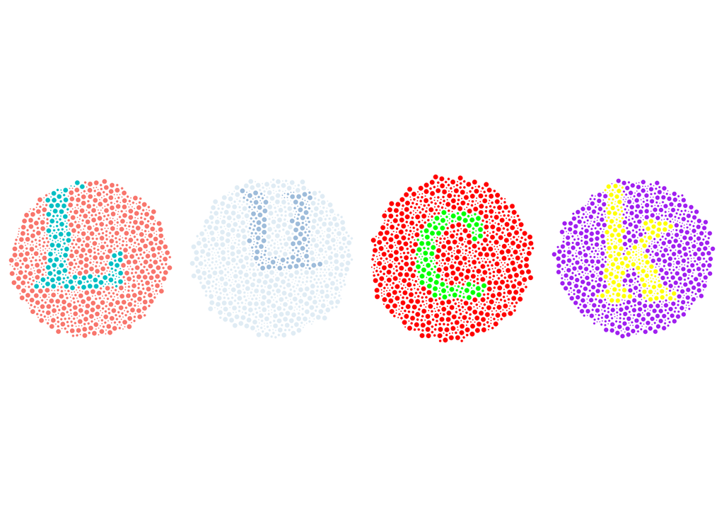

```r
if (!"ishihara" %in% installed.packages()) devtools::install_github("njtierney/ishihara")
library(ishihara)
library(ggplot2)

set.seed(20200510)
word <- strsplit("Luck", "")[[1]] # Split a word into letters
plots <- as.list(word) # Make lists to store the data/plots in
data <- as.list(word)
# Make a list of 4 different color scales
scales <- list(scale_fill_discrete(),
               scale_fill_brewer(palette = 3),
               scale_fill_manual(values = c("red", "green")),
               scale_fill_manual(values = c("purple", "yellow")))

# Compute the data
for(i in 1:length(word)) {
  data[[i]] <- ishihara_data(word[i])
}

# Make the plots
for(i in 1:length(word)) {
  plots[[i]] <- gg_ishihara(data[[i]]) + scales[[i]]
}

library(gridExtra) # Combine plots
grid.arrange(grobs = plots, ncol = 4)
```

### SAS Procedure: PROC TREE

Look through the [SAS Procedures Guide](https://go.documentation.sas.com/?docsetId=proc&docsetTarget=part-2.htm&docsetVersion=9.4&locale=en) (or [this](https://go.documentation.sas.com/?docsetId=proc&docsetTarget=p0ptdedyvyouspn1erbeqr0floca.htm&docsetVersion=9.4&locale=en) guide to procedures documented elsewhere) and find a procedure that is interesting to you that we haven’t yet discussed (which is most of them). Read the documentation of that procedure and demonstrate its use on a data set that is appropriate. Do not just copy the example code - actually explore what the procedure does. If you need code to get a dataset into SAS, check out [Module 4](https://srvanderplas.github.io/unl-stat850/reading-data.html#delimited-text-files), which has several chunks you can likely steal verbatim. There is also some sample ?data in the sashelp library.

Fill in your code in the chunk below.

[output not shown]

[output cut: 15 more lines]

[output not shown]

Average Linkage Cluster Analysis

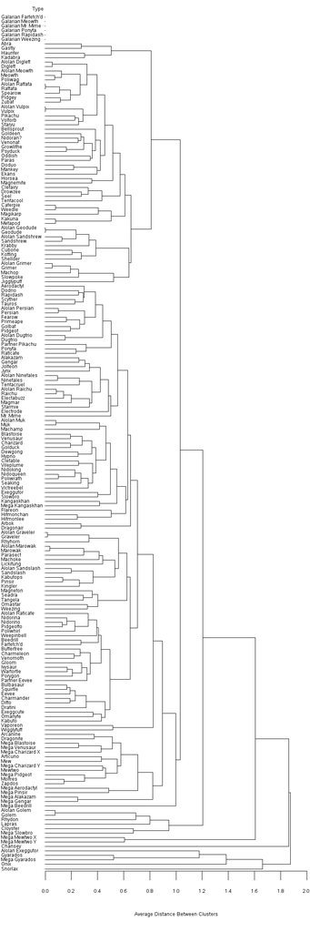